# Correlation Between European Stock Prices

Tong Wang  
Jan 25, 2015

### Bulls and bears: together, not the same

Stock prices around the world often rise and fall together. See below a plot of the daily closing prices of four major European stock indices: Germany DAX (Ibis), Switzerland SMI, France CAC, and UK FTSE from 1991 to 1998:

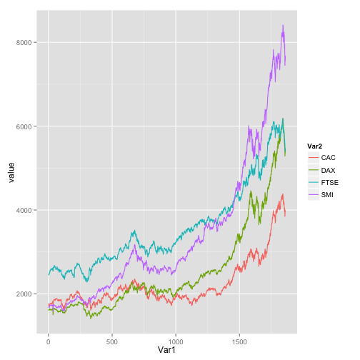

### Bulls and bears: together, not the same (cont'd)

We see that the four stock indices in general move hand in hand with each other. But how much exactly do they correlate with their European peers? We have built an app to help you investiage this.

Sneak preview: https://tongwang.shinyapps.io/DevelopingDataProducts/

### Specs

The application will then fit a linear regression model with the other three indices on the selected dates as predictors. The following are reported:

- Model R squared
- Plot of fitted and actual value

### Conclusion

You will see that all four indices show a very high correlation with the performace of the other Euorpean markets.

Enjoy!

https://tongwang.shinyapps.io/DevelopingDataProducts/